# Text Sentiment Analysis

Owais

2025-03-24

SOURCE CODE FOUND AT : https://chryswoods.com/text_analysis_r/

# Introduction

Sentiment analysis is the process of analyzing digital text to determine if the emotional tone of the message is positive, negative, or neutral. This project will showcase sentiment analysis performed in R. The purpose of the project is to gain a better and deeper insight into how sentiment analysis works.

## Installing Packages

First and most importantly, the relevant packages need to be installed as shown below.

```r
#install.packages("tidyverse")
#install.packages("tidytext")
#install.packages("ggraph")
#install.packages("igraph")
#install.packages("wordcloud")
#install.packages("textdata")
#install.packages("gutenbergr")
```

But what is the purpose of these packages? Let’s find out.

> Tidyverse : A collection of R packages designed for data science and data manipulation. Used for Cleaning, transforming, and visualizing data in a consistent and efficient way.

> Tidytext : Provides tools for text mining and text analysis in a tidy format. Breaking text into individual words (tokenization) and performing sentiment analysis.

> ggraph : An extension of ggplot2 for creating network graphs and other relational data visualizations. Creating a graph to show connections between characters in a novel.

> igraph : A package for creating and analyzing network graphs, e.g., social networks, word co-occurrence networks. Visualizing how often words appear together in a text.

> wordcloud : Generates word clouds, which are visual representations of word frequency in a text. Visualizing the most frequent words in a document or corpus.

> textdata : Provides access to text datasets and lexicons for text analysis. Useful for sentiment analysis, as it includes lexicons like AFINN, bing, and nrc. Loading sentiment lexicons to analyze the emotional tone of text.

> gutenbergr : Provides access to the Project Gutenberg collection of over 60,000 free eBooks. Downloading and analyzing works like Pride and Prejudice or Moby Dick.

## Loading Libraries

Now, it is time to load the libraries.

```r
library(tidyverse)
```

```r
library(tidytext)
library(ggraph)
library(igraph)
library(textdata)
library(gutenbergr)
library(wordcloud)
```

# TOKENIZATION

As explained earlier, tokenizing is breaking text into individual words for further analysis and to find out insights within the data. Let’s start by analyzing some famous lines from Hamlet’s famous soliloquy.

```r
text = c("To be, or not to be--that is the question:",
         "Whether 'tis nobler in the mind to suffer",
         "The slings and arrows of outrageous fortune",
         "Or to take arms against a sea of troubles",
         "And by opposing end them.")
```

Our next step is to convert this vector into a tibble. We want the tibble to have two columns:

1. *line* will hold the line number. There are five lines, so this will be the count from 1 to 5.
2. *text* will hold each line of text.

```r
text <- tibble(line=1:5, text=text)
text
```

```
## # A tibble: 5 × 2
##    line text
##   <int> <chr>
## 1     1 To be, or not to be--that is the question:
## 2     2 Whether 'tis nobler in the mind to suffer
## 3     3 The slings and arrows of outrageous fortune
## 4     4 Or to take arms against a sea of troubles
## 5     5 And by opposing end them.
```

Now it is time to rearrange this tibble into a tidy text format. Tidy data is data where:

1. every variable has its own column.
2. every observation has its own row.
3. each value must have its own cell.

So what is the “observation” when analyzing text? In tidy text, an observation is referred to as a “token”. A token is the smallest unit of text that you want to analyze. For example, a token could be individual letters, individual words, combination of neighboring words (n-grams), individual lines or individual paragraphs.The token is the smallest unit of text that you need to use for your analysis, i.e. the atomic unit. It is up to the user to decide what the appropriate token type is for your analysis. For example, if we were counting the number of times each word appeared in the text, then the token would be a word. If we were analyzing average line lengths, then the token would be a line.

For this analysis, the token, or observation, is a word. Each observation must have its own row, meaning that the tibble needs to be transformed so that there is one word per row. But what about the first rule that every variable has its own column? What are the variables for this text? There are two variables, The line number, which is in the column *line* and The actual token (word), which will be put in a column called *word*.

Therefore the tibble needs to be transformed so that there are two columns, *line* and *word*. Each word should be on a separate row. This could be done manually, fortunately however, the *tidytext* library supplies the function *unnest_tokens*, which can automatically do this.

```r
tokens <- text %>% unnest_tokens(word, text)
tokens
```

```
## # A tibble: 39 × 2
##     line word
##    <int> <chr>
##  1     1 to
##  2     1 be
##  3     1 or
##  4     1 not
##  5     1 to
##  6     1 be
##  7     1 that
##  8     1 is
##  9     1 the
## 10     1 question
## # ℹ 29 more rows
```

By default *unnest_tokens* will tokenize by words. This can be changed by passing different options to the function. The first argument is the name of the column in which to place the tokens, while the second argument is the name of the column that contains the text to tokenize.

Note that *unnest_tokens* has automatically lower-cased the words and removed punctuation. Now that the text is tidy, it is easy to count the number of occurrences of each word. This can be done using the ‘count’ function from tidyverse’s *dplyr* package. Pass *sort = TRUE* so that the resulting tibble is sorted with the most common words at the top.

```r
tokens %>% count(word, sort=TRUE)
```

```
## # A tibble: 30 × 2
##    word        n
##    <chr>   <int>
##  1 to          4
##  2 the         3
##  3 and         2
##  4 be          2
##  5 of          2
##  6 or          2
##  7 a           1
##  8 against     1
##  9 arms        1
## 10 arrows      1
## # ℹ 20 more rows
```

### Reading Text from a file

Tidying the text makes all subsequent analysis significantly easier. But before the text can be tidied, it has to be loaded into R. Typing it out into a vector, as done previously, would not be practical for large amounts of text. Fortunately R comes with many functions to read text from files. The *readLines* function from core R reads text from a file into a vector of lines.

```r
lines <- readLines("https://chryswoods.com/text_analysis_r/hamlet.txt")
lines
```

```
##  [1] "HAMLET"
##  [2] "A monologue from the play by William Shakespeare"
##  [3] ""
##  [4] "To be, or not to be--that is the question:"
##  [5] "Whether 'tis nobler in the mind to suffer"
##  [6] "The slings and arrows of outrageous fortune"
##  [7] "Or to take arms against a sea of troubles"
##  [8] "And by opposing end them. To die, to sleep--"
##  [9] "No more--and by a sleep to say we end"
## [10] "The heartache, and the thousand natural shocks"
## [11] "That flesh is heir to. 'Tis a consummation"
## [12] "Devoutly to be wished. To die, to sleep--"
## [13] "To sleep--perchance to dream: ay, there's the rub,"
## [14] "For in that sleep of death what dreams may come"
## [15] "When we have shuffled off this mortal coil,"
```

[output cut: 23 more lines]

Now to convert this into a tibble. One column, called *line*, will have the line number (from 1 to length(lines)), while the lines themselves will be placed into the column called *text*.

```r
hamlet <- tibble(line=1:length(lines), text=lines)
hamlet
```

```
## # A tibble: 38 × 2
##     line text
##    <int> <chr>
##  1     1 "HAMLET"
##  2     2 "A monologue from the play by William Shakespeare"
##  3     3 ""
##  4     4 "To be, or not to be--that is the question:"
##  5     5 "Whether 'tis nobler in the mind to suffer"
##  6     6 "The slings and arrows of outrageous fortune"
##  7     7 "Or to take arms against a sea of troubles"
##  8     8 "And by opposing end them. To die, to sleep--"
##  9     9 "No more--and by a sleep to say we end"
## 10    10 "The heartache, and the thousand natural shocks"
## # ℹ 28 more rows
```

Now tokenize the text using *unnest_tokens* again, and then count the numbers.

```r
hamlet_tokens <- hamlet %>% unnest_tokens(word, text)
hamlet_tokens %>% count(word, sort=TRUE)
```

```
## # A tibble: 172 × 2
##    word      n
##    <chr> <int>
##  1 the      21
##  2 of       15
##  3 to       15
##  4 and      12
##  5 that      7
##  6 a         6
##  7 sleep     5
##  8 be        4
##  9 we        4
## 10 bear      3
## # ℹ 162 more rows
```

Analysis is made difficult because the text contains lots of short words, like “the”, “of” and “and”, which form the scaffolding of the sentences without necessarily containing meaning in and of themselves. These words, which are often called “stop words”, are sometimes not needed for textual analysis, and should be removed. Fortunately the *tidytext* library provides a data set of English stop words.

```r
data(stop_words)
stop_words
```

```
## # A tibble: 1,149 × 2
##    word        lexicon
##    <chr>       <chr>
##  1 a           SMART
##  2 a's         SMART
##  3 able        SMART
##  4 about       SMART
##  5 above       SMART
##  6 according   SMART
##  7 accordingly SMART
##  8 across      SMART
##  9 actually    SMART
## 10 after       SMART
## # ℹ 1,139 more rows
```

These stop words can be removed from *hamlet_tokens* by performing an anti-join between *hamlet_tokens* and *stop_words*. An anti-join combines two tibbles, returning only the rows in the first tibble that are NOT in the second tibble. Now to use the *anti_join* function that is part of *dplyr*.

```r
important_hamlet_tokens <- hamlet_tokens %>% anti_join(stop_words)
important_hamlet_tokens
```

```
## # A tibble: 116 × 2
##     line word
##    <int> <chr>
##  1     1 hamlet
##  2     2 monologue
##  3     2 play
##  4     2 william
##  5     2 shakespeare
##  6     4 question
##  7     5 tis
##  8     5 nobler
##  9     5 mind
## 10     5 suffer
## # ℹ 106 more rows
```

Now, when the words are counted, only the meaningful words are shown.

```r
important_hamlet_tokens %>% count(word, sort=TRUE)
```

```
## # A tibble: 105 × 2
##    word       n
##    <chr>  <int>
##  1 sleep      5
##  2 bear       3
##  3 death      2
##  4 die        2
##  5 life       2
##  6 makes      2
##  7 tis        2
##  8 action     1
##  9 arms       1
## 10 arrows     1
## # ℹ 95 more rows
```

The top words, “sleep”, “death”, “die”, “life”, are a good insight into the meaning behind this speech.

All of the above steps can be combined into a single pipeline.

```r
hamlet %>% unnest_tokens(word, text) %>%
  anti_join(stop_words) %>%
  count(word, sort=TRUE)
```

```
## # A tibble: 105 × 2
##    word       n
##    <chr>  <int>
##  1 sleep      5
##  2 bear       3
##  3 death      2
##  4 die        2
##  5 life       2
##  6 makes      2
##  7 tis        2
##  8 action     1
##  9 arms       1
## 10 arrows     1
## # ℹ 95 more rows
```

### Downloading Text

To do more text analysis we need to find some larger texts. Fortunately, the *gutenbergr* package makes it easy to download books from *Project Gutenberg*.

Lets start by downloading **The Sufistic Quatrains of Omar Khayyam**. The Gutenberg ID of this book is **38511**.

```r
Omar <- gutenberg_download(38511)
```

```
## Determining mirror for Project Gutenberg from https://www.gutenberg.org/robot/harvest
```

```
## Using mirror http://aleph.gutenberg.org
```

```r
Omar
```

```
## # A tibble: 15,692 × 2
##    gutenberg_id text
##           <int> <chr>
##  1        38511 "  UNIVERSAL CLASSICS"
##  2        38511 "  LIBRARY"
##  3        38511 ""
##  4        38511 ""
##  5        38511 "  ILLUSTRATED"
##  6        38511 "  WITH PHOTOGRAVURES ON"
##  7        38511 "  JAPAN VELLUM, ETCHINGS"
##  8        38511 "  HAND PAINTED INDIA-PLATE"
##  9        38511 "  REPRODUCTIONS, AND"
## 10        38511 "  FULL PAGE PORTRAITS"
## # ℹ 15,682 more rows
```

Now to perform the same analysis as before, mainly tokenizing by word, removing stop words, and then counting words to find the most common ones.

```r
Omar <- Omar %>%
  unnest_tokens(word, text) %>%
  anti_join(stop_words)
```

Let’s now narrow down the words using *filter* function from dplyr to show words that appear more than 50 times.

```r
counts <- Omar %>%
  count(word, sort=TRUE) %>%
  filter(n > 50)

counts
```

```
## # A tibble: 47 × 2
##    word         n
##    <chr>    <int>
##  1 wine       579
##  2 thou       369
##  3 thy        269
##  4 drink      247
##  5 cup        214
##  6 world      201
##  7 life       188
##  8 day        181
##  9 quatrain   167
## 10 thee       165
## # ℹ 37 more rows
```

In order to plot this data, the words need to be converted into factors using the R *reorder* function. This will order the factors according to the number of occurrences of each word. As the tibble is being changed, The dplyr function *mutate* will be used to edit the column in place.

```r
counts <- counts %>% mutate(word = reorder(word, n))
```

The data is now ready to be plotted as a bar graph. This can be done by utilizing *ggplot* using the aesthetic of placing the number of occurrences on the x axis, the word on the y axis, using a *geom_col()* column plot, and not adding a label on the y-axis.

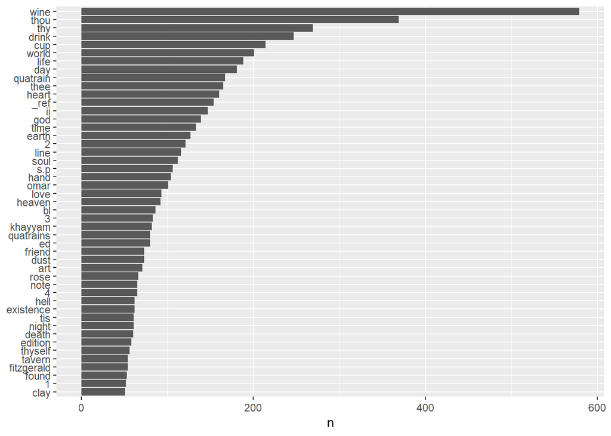

```r
counts %>% ggplot(aes(n, word)) + geom_col() + labs(y=NULL)
```

# SENTIMENT ANALYSIS

Sentiment analysis involves trying to analyse the feelings or sentiments expressed within a piece of text. Sentiments could be interpreted broadly, e.g. with words being classed as “positive” or “negative”, or more nuance could be included, e.g. with words classed as expressing “joy”, “fear”, “sadness” etc.

Sentiment analysis depends on building a dictionary of words and classifying those words according to sentiment. Several such dictionaries have been created, typically via crowd-sourcing or other large-scale analysis. The *tidytext* library provides the *get_sentiments* function. This can be used to download one of many different sentiments dictionaries into a tibble.

Amongst others, tidytext provides access to three general purpose sentiments dictionaries:

1. **AFINN** from **Finn Årup Nielsen**.
2. **bing** from **Bing Liu** and **collaborators**
3. **nrc** from **Saif Mohammad** and **Peter Turney**.

```r
sentiments <- get_sentiments("nrc")
sentiments
```

```
## # A tibble: 13,872 × 2
##    word        sentiment
##    <chr>       <chr>
##  1 abacus      trust
##  2 abandon     fear
##  3 abandon     negative
##  4 abandon     sadness
##  5 abandoned   anger
##  6 abandoned   fear
##  7 abandoned   negative
##  8 abandoned   sadness
##  9 abandonment anger
## 10 abandonment fear
## # ℹ 13,862 more rows
```

Choosing to follow these words for the sentiment analysis may not return accurate results. For example, badly is classified as **negative** and **sadness**, but in the sentence **I want that car badly.**, ‘badly’ is not necessarily negative or sadness. Also, some of these dictionaries of words are distributed under licenses (e.g. citation, payment etc), so that will also need to be accounted for if the user wishes to avail the services of these dictionaries.

Different dictionaries will use different sentiments, and will classify them in different ways. For *nrc* the sentiments are in the sentiments column.Tthe full list of sentiments and the number of words can be accessed and classified to each one via the *count* function.

```r
sentiments %>% count(sentiment)
```

```
## # A tibble: 10 × 2
##    sentiment        n
##    <chr>        <int>
##  1 anger         1245
##  2 anticipation   837
##  3 disgust       1056
##  4 fear          1474
##  5 joy            687
##  6 negative      3316
##  7 positive      2308
##  8 sadness       1187
##  9 surprise       532
## 10 trust         1230
```

## Matching sentiments to words

Sentiment analysis can be performed by attaching a sentiment to every word in a block of text. For example, let’s recreate the tidy text tibble of all of the non-stopwords in **Another Adventures of Sherlock Holmes, The Hound of the Baskervilles**.

```r
hound <- gutenberg_download(2852)%>%
  unnest_tokens(word, text) %>%
  anti_join(stop_words)
hound
```

```
## # A tibble: 18,681 × 2
##    gutenberg_id word
##           <int> <chr>
##  1         2852 cover
##  2         2852 hound
##  3         2852 baskervilles
##  4         2852 adventure
##  5         2852 sherlock
##  6         2852 holmes
##  7         2852 conan
##  8         2852 doyle
##  9         2852 dear
## 10         2852 robinson
## # ℹ 18,671 more rows
```

Each word can be classified depending on its sentiment by joining together the *hound* tibble with the dictionary of sentiments in *sentiments*. This can be done using dplyr’s *inner_join* function. This will join together two tibbles via their common column (in this case, word), creating new rows as needed if a word appears twice.

```r
hound_sentiment <- hound %>% inner_join(sentiments)
hound_sentiment
```

```
## # A tibble: 12,180 × 3
##    gutenberg_id word      sentiment
##           <int> <chr>     <chr>
##  1         2852 cover     trust
##  2         2852 adventure anticipation
##  3         2852 adventure positive
##  4         2852 dear      positive
##  5         2852 account   trust
##  6         2852 tale      positive
##  7         2852 curse     anger
##  8         2852 curse     disgust
##  9         2852 curse     fear
## 10         2852 curse     negative
## # ℹ 12,170 more rows
```

Observe how there is now a **sentiment** column added that shows repeated words which have multiple sentiments, e.g, “adventure” being classified as both “anticipation” and “positive”.

Now to count how many words of different sentiments there are using *filter* and *count*.

```r
hound_sentiment %>%
  filter(sentiment=="positive") %>%
  count(word, sort=TRUE)
```

```
## # A tibble: 596 × 2
##    word          n
##    <chr>     <int>
##  1 sir         351
##  2 friend       58
##  3 found        44
##  4 dear         36
##  5 fellow       33
##  6 brother      26
##  7 word         23
##  8 cab          21
##  9 reason       21
## 10 gentleman    20
## # ℹ 586 more rows
```

Now to get the total number of words of each type.

```r
hound_sentiment %>%
  filter(sentiment=="joy") %>%
  count(word) %>%
  summarise(total=sum(n))
```

```
## # A tibble: 1 × 1
##   total
##   <int>
## 1   730
```

Alternatively, the number of occurrences of each sentiment in the sentiments column can just be counted.

```r
hound_sentiment %>% count(sentiment)
```

```
## # A tibble: 10 × 2
##    sentiment        n
##    <chr>        <int>
##  1 anger          865
##  2 anticipation  1001
##  3 disgust        594
##  4 fear          1235
##  5 joy            730
##  6 negative      2033
##  7 positive      2429
##  8 sadness       1089
##  9 surprise       584
## 10 trust         1620
```

Now to plot our findings.

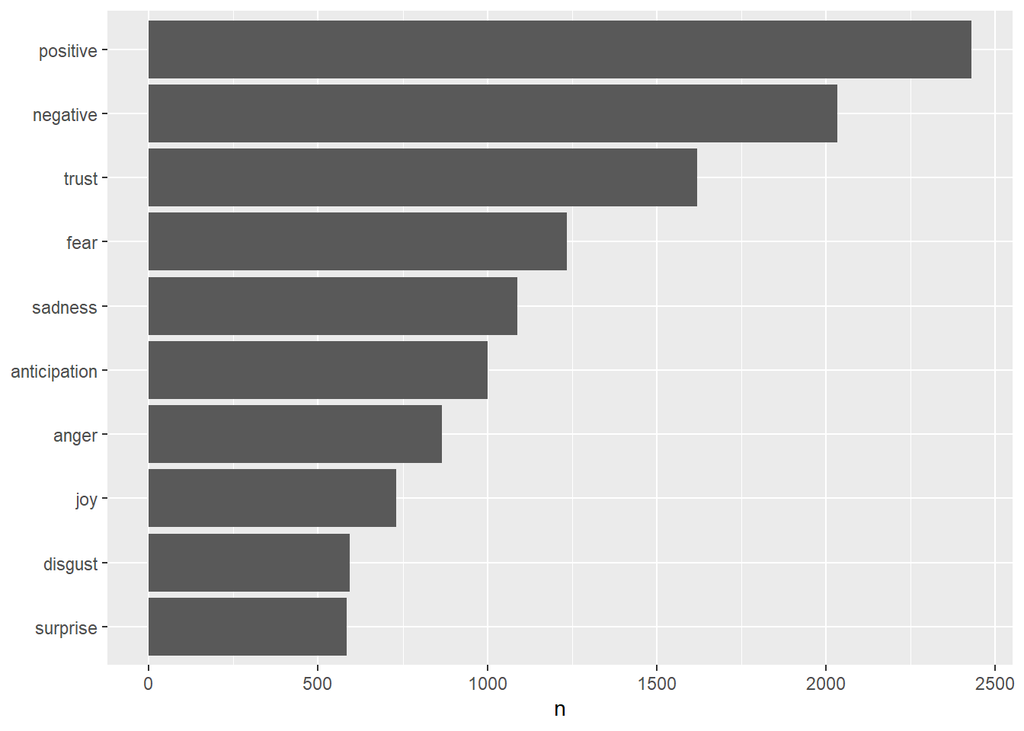

```r
hound_sentiment %>%
  count(sentiment) %>%
  mutate(sentiment = reorder(sentiment, n)) %>%
  ggplot(aes(n, sentiment)) + geom_col() + labs(y=NULL)
```

## Investigating change of sentiment through a text

Sentiment analysis can also be used to investigate how sentiment change throughout a text. To do this, first add a line number to each word in the text. This can be done my mutating the tibble downloaded from Project Gutenberg and adding a *linenumber* column which is just the row number in the tibble, obtained via the row_number function.

```r
hound <- gutenberg_download(2852) %>%
              mutate(linenumber=row_number()) %>%
              unnest_tokens(word, text) %>% anti_join(stop_words)
hound
```

```
## # A tibble: 18,681 × 3
##    gutenberg_id linenumber word
##           <int>      <int> <chr>
##  1         2852          1 cover
##  2         2852          5 hound
##  3         2852          5 baskervilles
##  4         2852          7 adventure
##  5         2852          7 sherlock
##  6         2852          7 holmes
##  7         2852         10 conan
##  8         2852         10 doyle
##  9         2852         15 dear
## 10         2852         15 robinson
## # ℹ 18,671 more rows
```

Now to add in the sentiments.

```r
hound_sentiments <- hound %>%
  inner_join(sentiments)
hound_sentiments
```

```
## # A tibble: 12,180 × 4
##    gutenberg_id linenumber word      sentiment
##           <int>      <int> <chr>     <chr>
##  1         2852          1 cover     trust
##  2         2852          7 adventure anticipation
##  3         2852          7 adventure positive
##  4         2852         15 dear      positive
##  5         2852         18 account   trust
##  6         2852         18 tale      positive
##  7         2852         39 curse     anger
##  8         2852         39 curse     disgust
##  9         2852         39 curse     fear
## 10         2852         39 curse     negative
## # ℹ 12,170 more rows
```

Our purpose here is to count the number of words with different sentiments for differnet blocks of the text. One way to do this is to divide the text up into blocks of multiple lines. The number of sentiments in each block can be counted, and then can be tracked on how this count changes from block to block in the text. Note that the choice of block size of 50 lines is random. It is best to experiment with different block sizes to see which number works best.

The block can be divided using *linenumber %/% 50* which will modulo divide each line number by 50. Thus lines 0-49 will be assigned to block 0, lines 50 to 99 to block 1 and so on.

```r
hound_blocks <- hound_sentiments %>%
  count(block=linenumber%/%50, sentiment)

hound_blocks
```

```
## # A tibble: 1,433 × 3
##    block sentiment        n
##    <dbl> <chr>        <int>
##  1     0 anger            3
##  2     0 anticipation     2
##  3     0 disgust          2
##  4     0 fear             3
##  5     0 joy              1
##  6     0 negative         3
##  7     0 positive         5
##  8     0 sadness          3
##  9     0 surprise         1
## 10     0 trust            4
## # ℹ 1,423 more rows
```

Next to pivot the tibble so that the sentiments are the columns, and we have one row per block of text. This is done using **pivot_wider** function from **tidyr** package. In this case, we want to pivot the tibble so that the names of the new columns come from the text values in the current “sentiment” column, and the values in those columns come from the current “n” column (which contains the number of words of each sentiment). It may be that some sentiments don’t appear in a block, so we need to ensure that any missing sentiments are filled in with a default value of 0.

```r
hound_blocks <- hound_blocks %>%
  pivot_wider(names_from = sentiment,
              values_from = n,
              values_fill = 0)

hound_blocks
```

```
## # A tibble: 147 × 11
##    block anger anticipation disgust  fear   joy negative positive sadness
##    <dbl> <int>        <int>   <int> <int> <int>    <int>    <int>   <int>
##  1     0     3            2       2     3     1        3        5       3
##  2     1     1            8       1     4     7        7       18       2
##  3     2     3            4       1     4     5       11       17       3
##  4     3     3            6       1    13     3        6       13      11
##  5     4     2            8       2     8     6        8       27       6
##  6     5     6            7       6    10     8       13       19      10
##  7     6     2            7       0     2     7        7       28       0
##  8     7     2            5       2     4     2        6       15       2
##  9     8    12            5       7    12     4       19       20       6
## 10     9    11            6       8    17     3       26       12      14
## # ℹ 137 more rows
## # ℹ 2 more variables: surprise <int>, trust <int>
```

Now to perform calculations of the difference between the number of positive and negative sentiments in each block, which could be placed into a new column called “sentiment”.

```r
hound_blocks <- hound_blocks %>%
  mutate(sentiment = positive - negative)

hound_blocks
```

```
## # A tibble: 147 × 12
##    block anger anticipation disgust  fear   joy negative positive sadness
##    <dbl> <int>        <int>   <int> <int> <int>    <int>    <int>   <int>
##  1     0     3            2       2     3     1        3        5       3
##  2     1     1            8       1     4     7        7       18       2
##  3     2     3            4       1     4     5       11       17       3
##  4     3     3            6       1    13     3        6       13      11
##  5     4     2            8       2     8     6        8       27       6
##  6     5     6            7       6    10     8       13       19      10
##  7     6     2            7       0     2     7        7       28       0
##  8     7     2            5       2     4     2        6       15       2
##  9     8    12            5       7    12     4       19       20       6
## 10     9    11            6       8    17     3       26       12      14
## # ℹ 137 more rows
## # ℹ 3 more variables: surprise <int>, trust <int>, sentiment <int>
```

This can be visually represented, with the “sentiment” column on the y axis, and the block number on the x axis.

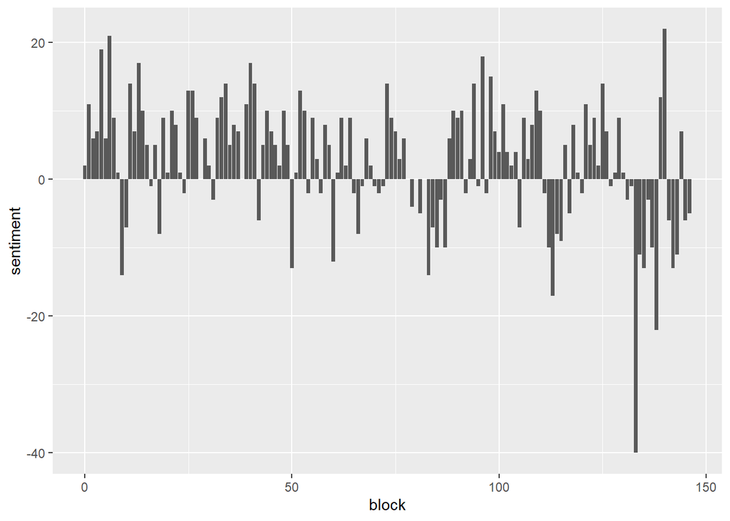

```r
hound_blocks %>% ggplot(aes(block, sentiment)) + geom_col()
```

This shows that **Another Adventures of Sherlock Holmes, The Hound of the Baskervilles** was more positive at the beginning, but had more periods of negativity as the text progressed.

The trajectory of specific sentiments can also be visualized.

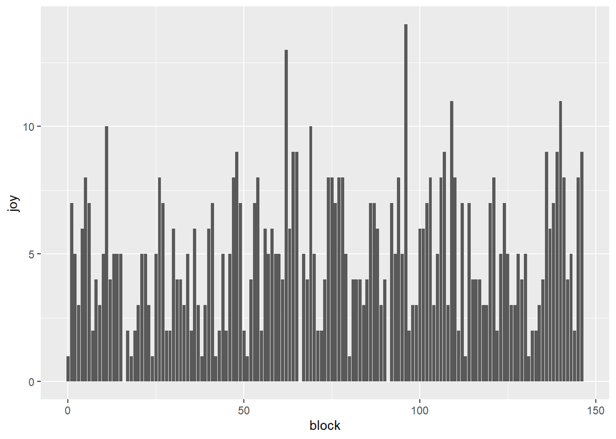

```r
hound_blocks %>% ggplot(aes(block, joy)) + geom_col()
```

# Regular Expressions

Searching and extracting text can be a complicated problem sometimes. Fortunately it has been solved by computer scientists, and has been adopted by most programming languages, including R. The solution is to use what are called “regular expressions”. Regular expressions may look complicated at a first glance, but are actually quite simple once the rules are understood. The syntax for regular expressions appeared and was standardised in the Perl language, and now nearly all programming languages support “Perl Compatible Regular Expressions” (PCRE).

In R, *str_detect* function is used from the *stringr* and regex is used to pass in regular expressions.

For example, let’s first read Hamlet’s monologue into a tibble.

```r
lines <- readLines("https://chryswoods.com/text_analysis_r/hamlet.txt")
text <- tibble(line=1:length(lines), text=lines)
```

Now *str_detect* can be used to filter out lines that contain specific text, e.g. the text “To” is going to be filtered out.

```r
text %>% filter(str_detect(text, "To"))
```

```
## # A tibble: 5 × 2
##    line text
##   <int> <chr>
## 1     4 To be, or not to be--that is the question:
## 2     8 And by opposing end them. To die, to sleep--
## 3    12 Devoutly to be wished. To die, to sleep--
## 4    13 To sleep--perchance to dream: ay, there's the rub,
## 5    25 To grunt and sweat under a weary life,
```

The opposite of this can also be done, i.e. filtering out all of the lines that do not have “To” by negating the search.

```r
text %>% filter(str_detect(text, "To", negate=TRUE))
```

```
## # A tibble: 33 × 2
##     line text
##    <int> <chr>
##  1     1 "HAMLET"
##  2     2 "A monologue from the play by William Shakespeare"
##  3     3 ""
##  4     5 "Whether 'tis nobler in the mind to suffer"
##  5     6 "The slings and arrows of outrageous fortune"
##  6     7 "Or to take arms against a sea of troubles"
##  7     9 "No more--and by a sleep to say we end"
##  8    10 "The heartache, and the thousand natural shocks"
##  9    11 "That flesh is heir to. 'Tis a consummation"
## 10    14 "For in that sleep of death what dreams may come"
## # ℹ 23 more rows
```

At the moment, this is performing a case-sensitive search. *regex* can be used to build a regular expression that searches for To in a case-insensitive way.

```r
text %>% filter(str_detect(text, regex("To", ignore_case=TRUE)))
```

```
## # A tibble: 10 × 2
##     line text
##    <int> <chr>
##  1     4 To be, or not to be--that is the question:
##  2     5 Whether 'tis nobler in the mind to suffer
##  3     7 Or to take arms against a sea of troubles
##  4     8 And by opposing end them. To die, to sleep--
##  5     9 No more--and by a sleep to say we end
##  6    11 That flesh is heir to. 'Tis a consummation
##  7    12 Devoutly to be wished. To die, to sleep--
##  8    13 To sleep--perchance to dream: ay, there's the rub,
##  9    25 To grunt and sweat under a weary life,
## 10    30 Than fly to others that we know not of?
```

Regular expressions can do more than just search for specific text. They can search for patterns of text. For example, what if the search for lines contained the word *the*? Lines where **the** is a part of a word would have to be excluded, such as *their* or *they*. To do this, use `\\b` to represent a word boundary (space, newline etc.). Then, search for `\\bthe\\b` to search for *word boundary* followed by *the* followed by *word boundary*.

```r
text %>% filter(str_detect(text, "\\bthe\\b"))
```

```
## # A tibble: 15 × 2
##     line text
##    <int> <chr>
##  1     2 A monologue from the play by William Shakespeare
##  2     4 To be, or not to be--that is the question:
##  3     5 Whether 'tis nobler in the mind to suffer
##  4    10 The heartache, and the thousand natural shocks
##  5    13 To sleep--perchance to dream: ay, there's the rub,
##  6    16 Must give us pause. There's the respect
##  7    18 For who would bear the whips and scorns of time,
##  8    19 Th' oppressor's wrong, the proud man's contumely
##  9    20 The pangs of despised love, the law's delay,
## 10    21 The insolence of office, and the spurns
## 11    26 But that the dread of something after death,
## 12    28 No traveller returns, puzzles the will,
## 13    32 And thus the native hue of resolution
## 14    33 Is sicklied o'er with the pale cast of thought,
## 15    36 And lose the name of action. -- Soft you now,
```

What if the lines to be detected contained *the* as a part of a word? In this case, use `\\w` to mean “any letter”, and thus `the\\w` would mean *the* followed by any letter.

```r
text %>% filter(str_detect(text, "the\\w"))
```

```
## # A tibble: 6 × 2
##    line text
##   <int> <chr>
## 1     5 Whether 'tis nobler in the mind to suffer
## 2     8 And by opposing end them. To die, to sleep--
## 3    13 To sleep--perchance to dream: ay, there's the rub,
## 4    29 And makes us rather bear those ills we have
## 5    30 Than fly to others that we know not of?
## 6    35 With this regard their currents turn awry
```

This has picked up whether, rather etc. What if the search contained all words that start with *the*? In this case, combine `\\b` and `\\w` to search for lines that contain *word boundary* followed by *the* followed by *any letter*.

```r
text %>% filter(str_detect(text, "\\bthe\\w"))
```

```
## # A tibble: 3 × 2
##    line text
##   <int> <chr>
## 1     8 And by opposing end them. To die, to sleep--
## 2    13 To sleep--perchance to dream: ay, there's the rub,
## 3    35 With this regard their currents turn awry
```

This has matched *them*, *there’s* and *their*.

There are many special characters that can be used. For example:

> `\\d` Match any digit (number)

> `\\s` Match a space

> `\\w` Match any word character (alphanumeric and “_”)

> `\\S` Match any non-whitespace character

> `\\D` Match any non-digit character

> `.` Match any character

> `\\t` Match a tab

> `\\n` Match a newline

Instead of using `\\w` to mean any letter, it can be used to actually ask to match specific letters. This is done by putting the letters to be matched between square brackets. For example, *[aiy]* would mean match any of *a*, *i* or *y*. Thus *th[aiy]* means match *th* followed by *a*, *i* or *y*.

```r
text %>% filter(str_detect(text, "th[aiy]"))
```

```
## # A tibble: 8 × 2
##    line text
##   <int> <chr>
## 1     4 To be, or not to be--that is the question:
## 2    14 For in that sleep of death what dreams may come
## 3    15 When we have shuffled off this mortal coil,
## 4    22 That patient merit of th' unworthy takes,
## 5    26 But that the dread of something after death,
## 6    30 Than fly to others that we know not of?
## 7    35 With this regard their currents turn awry
## 8    37 The fair Ophelia! -- Nymph, in thy orisons
```

Characters that are matched in the square brackets can be controlled using:

> `[abc]` Match a, b or c

> `[a-z]` Match any character between a to z

> `[A-Z]` Match any character between A to Z

> `[a-zA-Z]` Match any character from a to z and A to Z (any letter)

> `[0-9]` Match any digit

> `[02468]` Match any even digit

> `[^0-9]` Matches NOT digits (^ means NOT)

Repition can also be used when matching.

> `*` Match 0 or more times, e.g. `\\w*` means match 0 or more word characters.

> `+` Match 1 or more times, e.g. `\\w+` means match 1 or more word characters.

> `?` Match 0 or 1 times, e.g. `\\w?` means match 0 or 1 word characters.

> `{n}` Match exactly n times, e.g. `\\w{3}` means match exactly 3 word characters.

> `{n,}` Match at least n times, e.g. `\\w{5,}` means match at least 5 word characters.

> `{m,n}` Match between m and n times, e.g. `\\w{5,7}` means match 5-7 word characters.

For example, let’s use the above rules to find all lines that contain words with 10-12 characters.

```r
text %>% filter(str_detect(text, "\\w{10,12}"))
```

```
## # A tibble: 8 × 2
##    line text
##   <int> <chr>
## 1     2 A monologue from the play by William Shakespeare
## 2     6 The slings and arrows of outrageous fortune
## 3    11 That flesh is heir to. 'Tis a consummation
## 4    27 The undiscovered country, from whose bourn
## 5    31 Thus conscience does make cowards of us all,
## 6    32 And thus the native hue of resolution
## 7    34 And enterprise of great pitch and moment
## 8    38 Be all my sins remembered.
```

These rules can also be applied to sequence of characters, by putting them in round brackets. This is particularly useful when combined with `|`, which means “or”. For example,

```r
text %>% filter(str_detect(text, "(monologue)|(dream)"))
```

```
## # A tibble: 3 × 2
##    line text
##   <int> <chr>
## 1     2 A monologue from the play by William Shakespeare
## 2    13 To sleep--perchance to dream: ay, there's the rub,
## 3    14 For in that sleep of death what dreams may come
```

has matched **monologue** or **dream**. Combining this with the modifiers above gives us:

```r
text %>% filter(str_detect(text, "\\b(T|t)he(re)?\\b"))
```

```
## # A tibble: 18 × 2
##     line text
##    <int> <chr>
##  1     2 A monologue from the play by William Shakespeare
##  2     4 To be, or not to be--that is the question:
##  3     5 Whether 'tis nobler in the mind to suffer
##  4     6 The slings and arrows of outrageous fortune
##  5    10 The heartache, and the thousand natural shocks
##  6    13 To sleep--perchance to dream: ay, there's the rub,
##  7    16 Must give us pause. There's the respect
##  8    18 For who would bear the whips and scorns of time,
##  9    19 Th' oppressor's wrong, the proud man's contumely
## 10    20 The pangs of despised love, the law's delay,
## 11    21 The insolence of office, and the spurns
## 12    26 But that the dread of something after death,
## 13    27 The undiscovered country, from whose bourn
## 14    28 No traveller returns, puzzles the will,
## 15    32 And thus the native hue of resolution
## 16    33 Is sicklied o'er with the pale cast of thought,
## 17    36 And lose the name of action. -- Soft you now,
## 18    37 The fair Ophelia! -- Nymph, in thy orisons
```

which matches a word boundary, followed by `T` or `t`, followed by `he` followed by zero or one `re` followed by a word boundary. As such, it has matched the words `The`, `the`, `There` and `there`.

We can also specify that a match must be made at the beginning of the line using `^`. This means match at the start of the line. Here we get all of the lines that start with `The`.

```r
text %>% filter(str_detect(text, "^The"))
```

```
## # A tibble: 6 × 2
##    line text
##   <int> <chr>
## 1     6 The slings and arrows of outrageous fortune
## 2    10 The heartache, and the thousand natural shocks
## 3    20 The pangs of despised love, the law's delay,
## 4    21 The insolence of office, and the spurns
## 5    27 The undiscovered country, from whose bourn
## 6    37 The fair Ophelia! -- Nymph, in thy orisons
```

Similarly, use `$` to mean match at the end of the line. Here we get all lines that end with `on`.

```r
text %>% filter(str_detect(text, "on$"))
```

```
## # A tibble: 2 × 2
##    line text
##   <int> <chr>
## 1    11 That flesh is heir to. 'Tis a consummation
## 2    32 And thus the native hue of resolution
```

## Replacing text

As well as searching for text, regular expressions can also be used to replace text. This can be done using *stringrs* *str_replace* or *str_replace_all* functions. Following is the syntax : **str_replace(line, pattern, replace)**

For example, the above syntax will replace the first instance of `pattern` in `line` with `replace`.

```r
line <- text[4, 2]

str_replace(line, "be", "bandanas")
```

```
## [1] "To bandanas, or not to be--that is the question:"
```

We can also choose to match the string to replace using a regex, For example :

```r
str_replace_all(line, regex("to be", ignore_case=TRUE), "nuts")
```

```
## [1] "nuts, or not nuts--that is the question:"
```

we need to use `mutate` to apply this change to all rows in a tibble. For example :

```r
text %>% mutate(text = str_replace_all(text, "be", "bandanas"))
```

```
## # A tibble: 38 × 2
##     line text
##    <int> <chr>
##  1     1 "HAMLET"
##  2     2 "A monologue from the play by William Shakespeare"
##  3     3 ""
##  4     4 "To bandanas, or not to bandanas--that is the question:"
##  5     5 "Whether 'tis nobler in the mind to suffer"
##  6     6 "The slings and arrows of outrageous fortune"
##  7     7 "Or to take arms against a sea of troubles"
##  8     8 "And by opposing end them. To die, to sleep--"
##  9     9 "No more--and by a sleep to say we end"
## 10    10 "The heartache, and the thousand natural shocks"
## # ℹ 28 more rows
```

```r
text %>% mutate(text = str_replace_all(text, regex("\\bthe\\b", ignore_case=TRUE), "bandanas"))
```

```
## # A tibble: 38 × 2
##     line text
##    <int> <chr>
##  1     1 "HAMLET"
##  2     2 "A monologue from bandanas play by William Shakespeare"
##  3     3 ""
##  4     4 "To be, or not to be--that is bandanas question:"
##  5     5 "Whether 'tis nobler in bandanas mind to suffer"
##  6     6 "bandanas slings and arrows of outrageous fortune"
##  7     7 "Or to take arms against a sea of troubles"
##  8     8 "And by opposing end them. To die, to sleep--"
##  9     9 "No more--and by a sleep to say we end"
## 10    10 "bandanas heartache, and bandanas thousand natural shocks"
## # ℹ 28 more rows
```

## Caution

Regular expressions are powerful, as we have seen. They can be used to search for specific output from the project and performs powerful text manipulation. However, they are “write-only”. Extremely difficult to understand for non-experts, and complex regular expressions can be difficult even for seasoned programmers and coders. One good practice is to **ALWAYS** comment the regular expressions and explain in English exactly what the intention was when the expression was written. Once the rules are memorized and understood, regular expressions will not be as complicated to read and understand. However, without comments, they will be completely unintelligible to everyone else who looks at or relies on the provided code.